# Analysis of TCGA Lung Squamous Cell Carcinoma (LUSC)

Estefania Mancini

May 2020

```r
library(ggplot2)
library(survival)
library(knitr)
library(kableExtra)
library(survminer)
library(ggfortify)
library(psichomics)
library(xtable)
```

# 1 Introduction

The Cancer Genome Atlas (TCGA, https://www.cancer.gov/about-nci/organization/ccg/research/structural-genomics/tcga), molecularly characterized over 20,000 primary cancer and matched normal samples spanning 33 cancer types.

# 2 Data

- Raw data is available under folder <“data”>
- Serrano’s group shared with us the tables of the splicing events for LUNG cancer produced using (https://github.com/vastgroup/vast-tools). We extratcted PSI for NUMB EXON 9 (HsaEX0044216) as well as coversion tables for samples and clinical data (see <“../data/psi_lung_NA_NewN3.tab”/)
- Clinical data was obtained using psichomics (see https://www.bioconductor.org/packages/release/bioc/html/psichomics.html). See <../data/luad_clinical_psichomics.tab>.
- nrow=503 (samples)
- ncol=2169 (features)
- adin.disease_code=LUSC

```r
subset$newVar<-paste(subset$stage,
                     subset$gender, sep="_")

dfAg1<-data.frame(table(subset$newVar))
#Var1 viene del table
dfAg1<-cbind(dfAg1,
             data.frame(matrix(unlist(strsplit(as.character(dfAg1$Var1), "_")), ncol=2, byrow = T)))

colnames(dfAg1)[1]<-"comb"
colnames(dfAg1)[2]<-"NumOfSamples"
colnames(dfAg1)[3]<-"stage"
colnames(dfAg1)[4]<-"gender"

knitr::kable(dfAg1[,2:4], format="pandoc", align='cccc')
```

| NumOfSamples | stage | gender |
| --- | --- | --- |
| 1 | i | female |
| 2 | i | male |
| 35 | ia | female |
| 54 | ia | male |
| 34 | ib | female |
| 118 | ib | male |
| 1 | ii | female |
| 2 | ii | male |
| 13 | iia | female |
| 52 | iia | male |
| 26 | iib | female |
| 69 | iib | male |
| 3 | iii | female |
| 15 | iiia | female |
| 48 | iiia | male |
| 2 | iiib | female |
| 17 | iiib | male |
| 1 | iv | female |
| 6 | iv | male |
| 4 | NA | male |

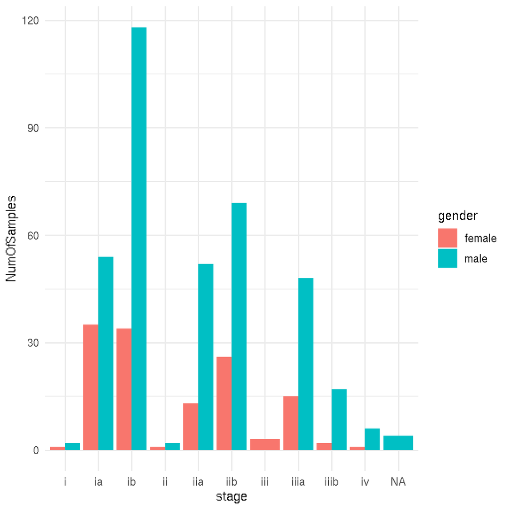

```r
ggplot(data=dfAg1, aes(x=stage, y=NumOfSamples, fill=gender)) +
  geom_bar(stat="identity",  position="dodge")+
  theme_minimal()
```

```r
subset$newVar2<-paste(subset$aggStage,
                      subset$gender,
                      sep="_")
dfAg2<-data.frame(table(subset$newVar2))
#Var1 viene del table
dfAg2<-cbind(dfAg2,
             data.frame(matrix(unlist(strsplit(as.character(dfAg2$Var1), "_")), ncol=2, byrow = T)))

colnames(dfAg2)[1]<-"comb"
colnames(dfAg2)[2]<-"NumOfSamples"
colnames(dfAg2)[3]<-"aggStage"
colnames(dfAg2)[4]<-"gender"

knitr::kable(dfAg2, format="pandoc", align='cccc')
```

| comb | NumOfSamples | aggStage | gender |
| --- | --- | --- | --- |
| early_female | 110 | early | female |
| early_male | 297 | early | male |
| late_female | 21 | late | female |
| late_male | 71 | late | male |
| NA_male | 4 | NA | male |

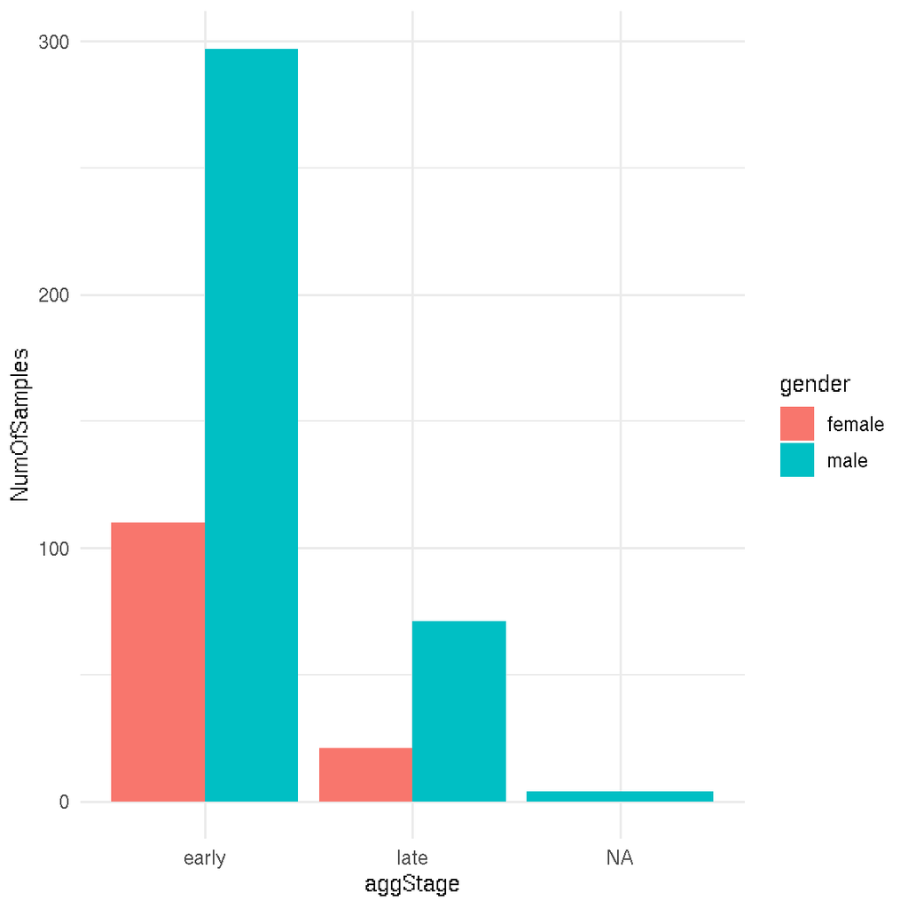

```r
ggplot(data=dfAg2, aes(x=aggStage, y=NumOfSamples, fill=gender)) +
  geom_bar(stat="identity",  position="dodge")+
  theme_minimal()
```

# 3 Descriptive

Here we analyze PSI distribution using several clinical variables

## 3.1 Statistical tests

We use:

- Wilcoxon test wilcox.test() Compare two groups (non-parametric)
- Kruskal-Wallis kruskal.test() Compare multiple groups (non-parametric)

See http://www.sthda.com/english/articles/24-ggpubr-publication-ready-plots/76-add-p-values-and-significance-levels-to-ggplots/

## 3.2 Analysis by type: normal or tumoral tissue (samples)

For the first analysis we compared the levels of NUMB exon 9 inclusion between healthy and tumoral tissue. In total 109 healthy samples (mean PSI 6.14) vs 494 tumoral samples (mean PSI 35) were compared using a Wilcoxon test.

This data suggests that lung tumors have a (significant) higher NUMB exon 9 PSI value than healthy tissue (p-value < 2.2e-16).

```r
normal<-dfPlots[dfPlots$type=="normal",]
print(paste("N normal:",dim(normal)[1]))
```

```
## [1] "N normal: 109"
```

```r
print(paste("Mean normal:",mean(normal$psi)))
```

```
## [1] "Mean normal: 6.14688073394495"
```

```r
tumor<-dfPlots[dfPlots$type=="tumor",]
print(paste("N tumoral:",dim(tumor) [1]))
```

```
## [1] "N tumoral: 494"
```

```r
print(paste("Mean tumoral:",mean(tumor$psi)))
```

```
## [1] "Mean tumoral: 34.9767611336032"
```

```r
wilcox.test(normal$psi, tumor$psi)
```

```
##
##  Wilcoxon rank sum test with continuity correction
##
## data:  normal$psi and tumor$psi
## W = 910.5, p-value < 2.2e-16
## alternative hypothesis: true location shift is not equal to 0
```

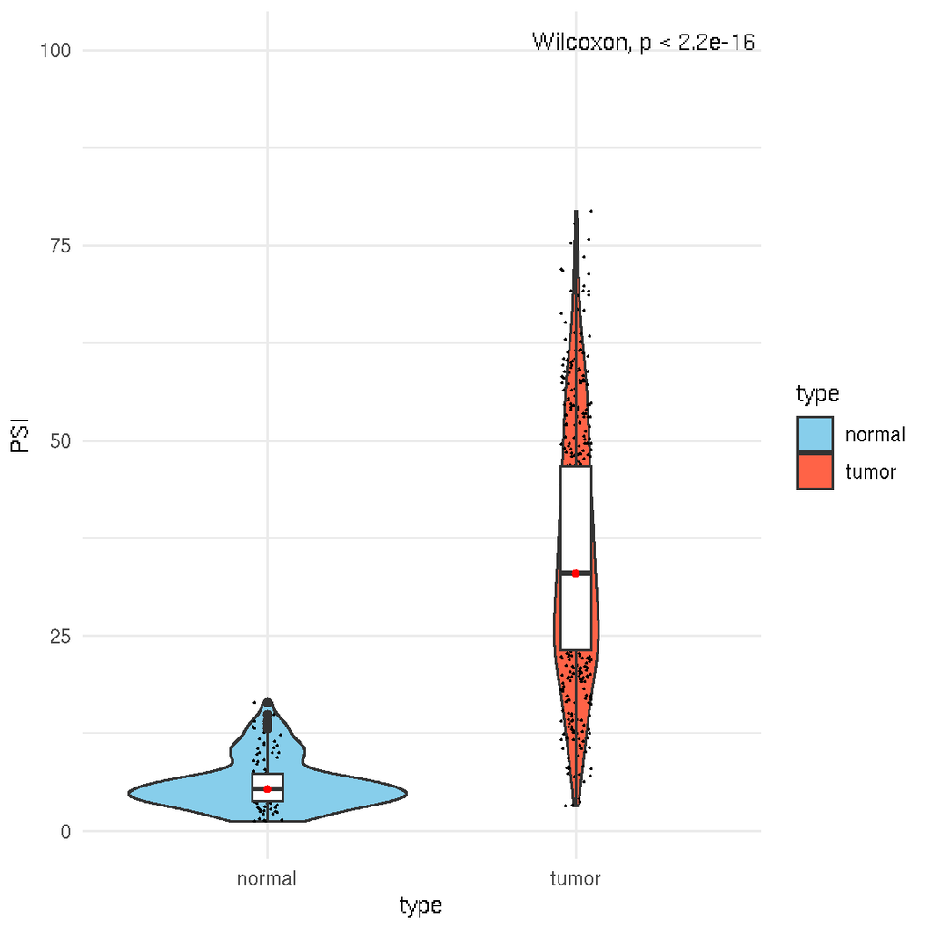

```r
numb_psi<-dfPlots[,1:2]
colnames(numb_psi) <- c("PSI","type")
ggplot(data= numb_psi, aes(x=type,y=PSI)) + geom_violin(aes(fill=type)) +
  scale_colour_manual(values = c("skyblue", "tomato")) +
  scale_fill_manual(values = c("skyblue", "tomato")) +
  theme(axis.text.x = element_text(angle = 90, hjust = 1))+
  geom_jitter(shape=16,
              position=position_jitter(0.05),
              size=.5,
              color=  "black")+
  geom_boxplot(width=0.1) +
  stat_summary(fun=median, geom="point", size=1, color="red")+   stat_compare_means(label.y = 100, label.x=2)+
  theme_minimal()
```

### 3.2.1 GTEX (caterina)

We also analyzed PSI value in healthy tissues, using The Genotype-Tissue Expression (GTEx) project data (https://www.gtexportal.org/home/)

- Vast-tool hg19,PSI range: 0-100
- median PSI values across lung samples = 3.52%
- mean PSI values across lung samples= 3.52%
- Range PSI values across lung samples= 20%

This data suggest PSI in healthy tissues is ~3.5 %

## 3.3 Analysis by stage

We analyzed PSI values according to their tumoral stage (provided in the clinical data) using a kruskal.test(). We didn’t find any significant differences between them according kruskal test (pval = 0.24)

```
##
##    i   ia   ib   ii  iia  iib  iii iiia iiib   iv
##    3   87  148    3   65   94    3   62   18    7
```

```
##
##  Kruskal-Wallis rank sum test
##
## data:  psi by stage
## Kruskal-Wallis chi-squared = 11.434, df = 9, p-value = 0.2471
```

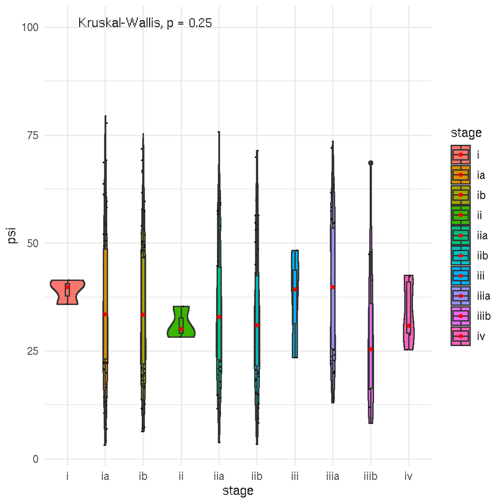

- (Now, re plot ordering by median, to improve visualization):

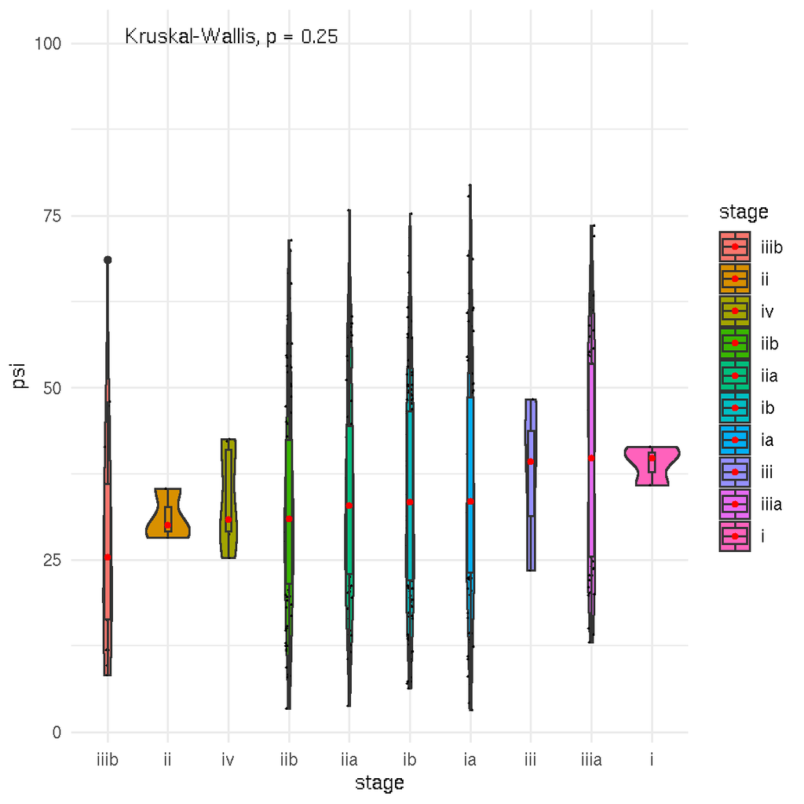

- **Results**: According Kruskal-Wallis ( p-value = 0.25) there is no clear stage with (high) different psi.

## 3.4 Analysis by Aggregate stage

- **Results**: despite Late stage seems to has higher PSI, there is not a significant difference according to Wilcoxon test p-value = 0.1856)

```
##
## early  late
##   400    90
```

```
##
##  Wilcoxon rank sum test with continuity correction
##
## data:  finalVNotNA$psi[finalVNotNA$aggStage == "early"] and finalVNotNA$psi[finalVNotNA$aggStage == "late"]
## W = 16393, p-value = 0.1856
## alternative hypothesis: true location shift is not equal to 0
```

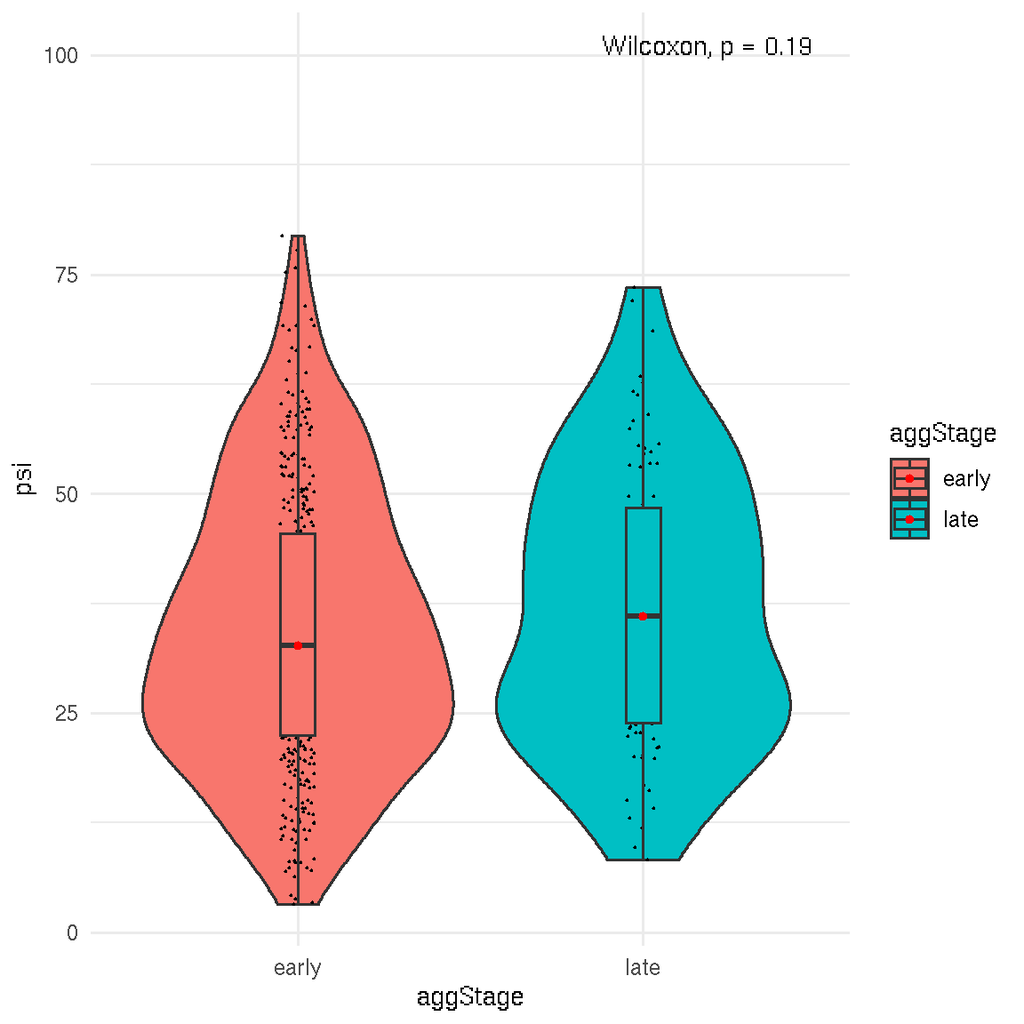

## 3.5 Analysis by gender

- **Results** We didnt find signtificant difference in PSI between male and female samples ( p-value = 0.8514)

```
##
## female   male
##    128    362
```

```
##
##  Wilcoxon rank sum test with continuity correction
##
## data:  finalVNotNA$psi[finalVNotNA$gender == "male"] and finalVNotNA$psi[finalVNotNA$gender == "female"]
## W = 23426, p-value = 0.8514
## alternative hypothesis: true location shift is not equal to 0
```

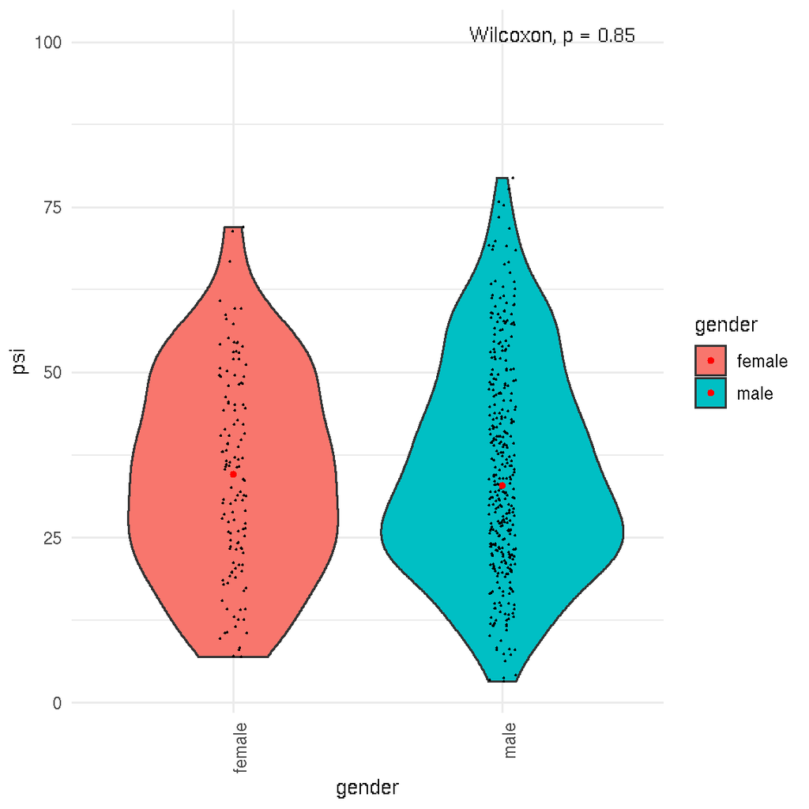

## 3.6 Analysis by gender and aggregate stage

```
## [1] "Early by gender:"
```

```
##
## female   male
##    108    292
```

```
## [1] "Late by gender:"
```

```
##
## female   male
##     20     70
```

```
## [1] "Kruskal-Wallis test:"
```

```
##
##  Kruskal-Wallis rank sum test
##
## data:  psi by gender
## Kruskal-Wallis chi-squared = 0.012224, df = 1, p-value = 0.912
```

```
##
##  Kruskal-Wallis rank sum test
##
## data:  psi by gender
## Kruskal-Wallis chi-squared = 0.037677, df = 1, p-value = 0.8461
```

```
## [1] "Wilcoxon test:"
```

```
##
##  Wilcoxon rank sum test with continuity correction
##
## data:  early$psi[early$gender == "male"] and early$psi[early$gender == "female"]
## W = 15882, p-value = 0.9123
## alternative hypothesis: true location shift is not equal to 0
```

```
##
##  Wilcoxon rank sum test with continuity correction
##
## data:  late$psi[late$gender == "male"] and late$psi[late$gender == "female"]
## W = 720, p-value = 0.8499
## alternative hypothesis: true location shift is not equal to 0
```

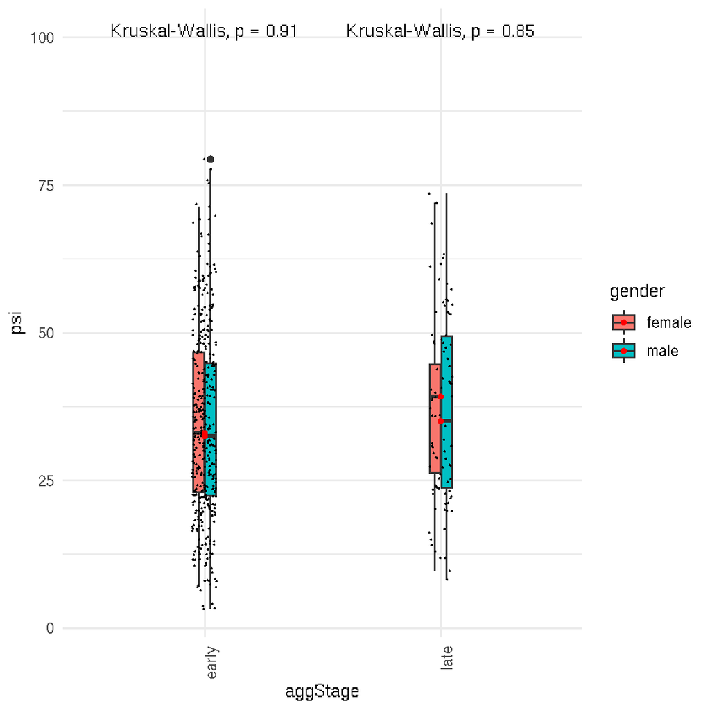

## 3.7 Correlation between NUMB exon 9 PSI and known LUAD driver mutations

Some of the most known cancer-related mutations are also clinically measured in the patients. We performed a correlation analysis to try to identify if there is any correlation between NUMB exon 9 inclusion levels and mutations in known genes.

We found reported mutations in these genes:

### 3.7.1 *egfr*

Samples with mutation analysis performed: * YES: 21, + l858 1 + ns 19 + other 1

- NO: 473 (NAs were replaced by “NO”)
- (1 yes vs no) There is not statistically significant differences between these 2 groups (p-value = 0.2643).

```
##
##  no yes
## 473  21
```

```
##
##  Kruskal-Wallis rank sum test
##
## data:  finalV$psi by finalV$egfr_mutation_performed
## Kruskal-Wallis chi-squared = 1.2459, df = 1, p-value = 0.2643
```

```
##
## l858r    ns other
##     1    19     1
```

```
##
##  Kruskal-Wallis rank sum test
##
## data:  finalVE$psi by finalVE$egfr_mutation_result
## Kruskal-Wallis chi-squared = 0.98428, df = 2, p-value = 0.6113
```

- (2 yes) There is not statistically significant differences (p-value = 0.6113).

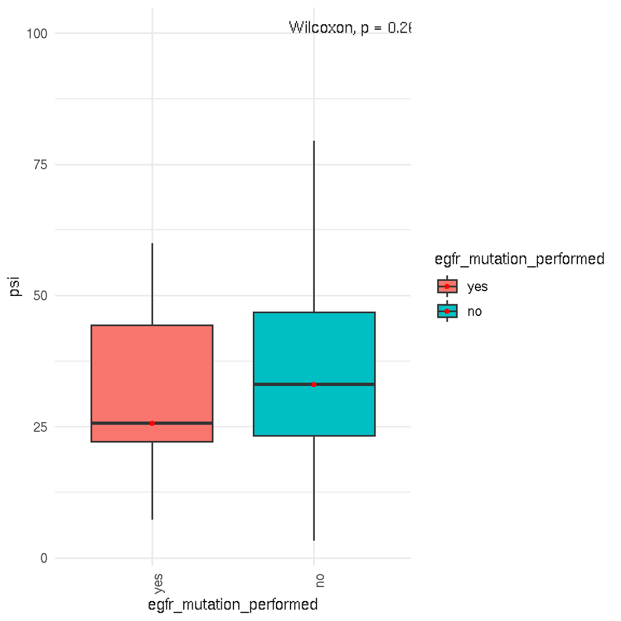

```r
ggplot(finalV, aes(x=egfr_mutation_performed, y=psi, fill=egfr_mutation_performed))+
  geom_boxplot()   +
  #geom_jitter(shape=16,                position=position_jitter(0.05), size=.5,  color=  "black")+
  stat_summary(fun=median, geom="point", size=1, color="red")+     stat_compare_means(label.y = 100, label.x=2)+
  theme_minimal()+
  theme(axis.text.x = element_text(angle = 90, hjust = 1))
```

- (2, only yes) Mutation results (reorder by median PSI):

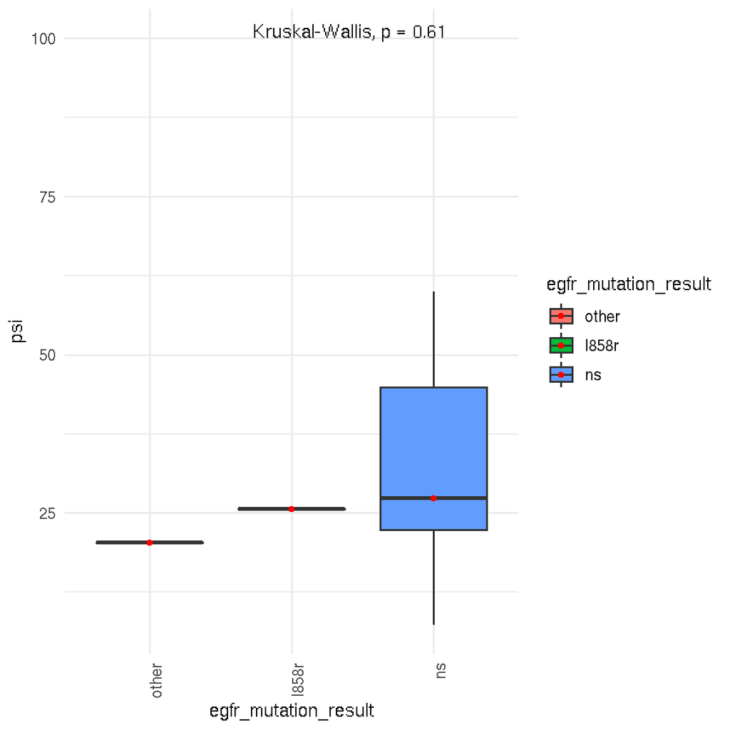

```r
finalVE$egfr_mutation_result = with(finalVE, reorder(egfr_mutation_result, psi, median))

ggplot(finalVE, aes(x=egfr_mutation_result, y=psi, fill=egfr_mutation_result))+
  geom_boxplot()   +
  #geom_jitter(shape=16,                position=position_jitter(0.05), size=.5,  color=  "black")+
  stat_summary(fun=median, geom="point", size=1, color="red")+    stat_compare_means(label.y = 100, label.x=2)+
  theme_minimal()+
  theme(axis.text.x = element_text(angle = 90, hjust = 1))
```

### 3.7.2 *kras*

- KRAS mutation performed: 493 no, 1 yes -> other

### 3.7.3 *alk*

- **Results**: We found 9 cases where Eml4_alk_translocation was performed (4 fish)

## 3.8 Treatment Success

We also explored the PSI in different groups according their treatment success:

### 3.8.1 (1) Follow up: follow up treatment success

- Variable name: follow_ups.follow_up.followup_treatment_success
- **Results**: Despite we didnt find significant differences (pval 0.19), it seems PSI is slighly higher at progressive stages.

```r
finalV$follow_ups.follow_up.followup_treatment_success<-
  as.character(finalV$follow_ups.follow_up.followup_treatment_success)

finalV$follow_ups.follow_up.followup_treatment_success[is.na(finalV$follow_ups.follow_up.followup_treatment_success)]<-"unknown"


print(
  table(finalV$follow_ups.follow_up.followup_treatment_success))
```

```
##
## complete remission/response  partial remission/response
##                         162                           2
##         progressive disease              stable disease
##                          59                          13
##                     unknown
##                         258
```

```r
##########################################################
#remuevo los unknown
clean<-finalV[finalV$follow_ups.follow_up.followup_treatment_success!="unknown",]
#remuevo los partial remission response
clean<-clean[clean$follow_ups.follow_up.followup_treatment_success!="partial remission/response",]
dim(clean)#234
```

```
## [1] 234  37
```

```r
table(clean$follow_ups.follow_up.followup_treatment_success)
```

```
##
## complete remission/response         progressive disease
##                         162                          59
##              stable disease
##                          13
```

```r
clean$follow_ups.follow_up.followup_treatment_success<-
  factor(clean$follow_ups.follow_up.followup_treatment_success,
         c("complete remission/response",
           "stable disease","progressive disease"))
###########################################################
```

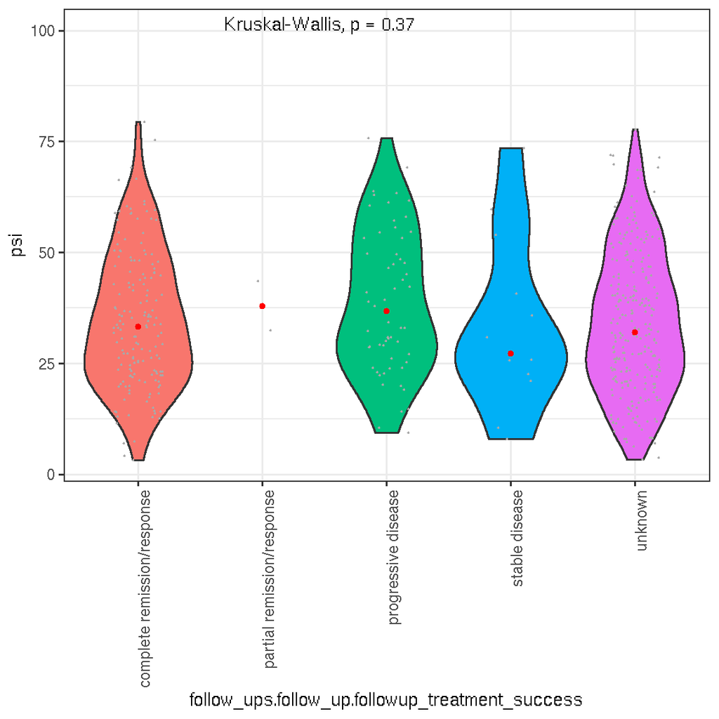

```r
ggplot(finalV,
       aes(x=follow_ups.follow_up.followup_treatment_success,
           y=psi,
           fill=follow_ups.follow_up.followup_treatment_success))+
  geom_violin()   +
  theme_bw()+
  geom_jitter(shape=16,
              position=position_jitter(0.2),
              size=.5, color="darkgrey")     +
  stat_summary(fun=median, geom="point", size=1, color="red")  +
  stat_compare_means(label.y = 100, label.x=2)+
  theme(legend.position="none") +
  theme(axis.text.x = element_text(angle = 90, hjust = 1))
```

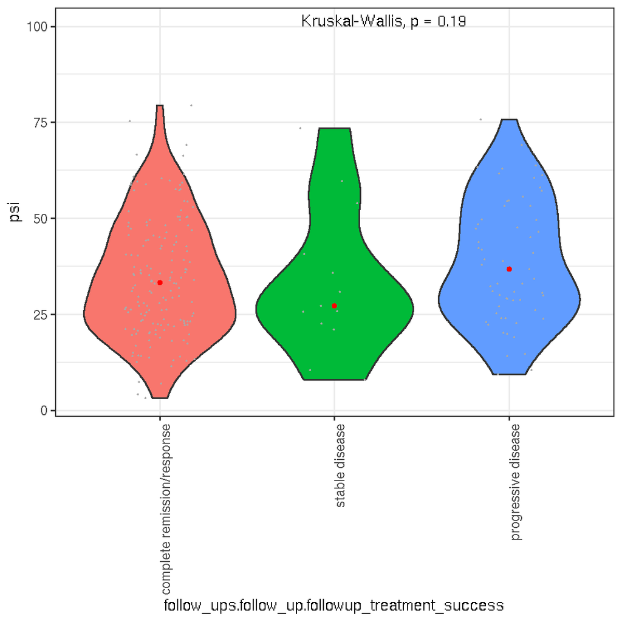

```r
ggplot(clean,
       aes(x=follow_ups.follow_up.followup_treatment_success,
           y=psi,
           fill=follow_ups.follow_up.followup_treatment_success))+
  geom_violin()   +
  theme_bw()+
  geom_jitter(shape=16,
              position=position_jitter(0.2),
              size=.5, color="darkgrey")     +
  stat_summary(fun=median, geom="point", size=1, color="red")  +
  stat_compare_means(label.y = 100, label.x=2)+
  theme(legend.position="none") +
  theme(axis.text.x = element_text(angle = 90, hjust = 1))
```

- (1b) Repito reorder by median PSI:

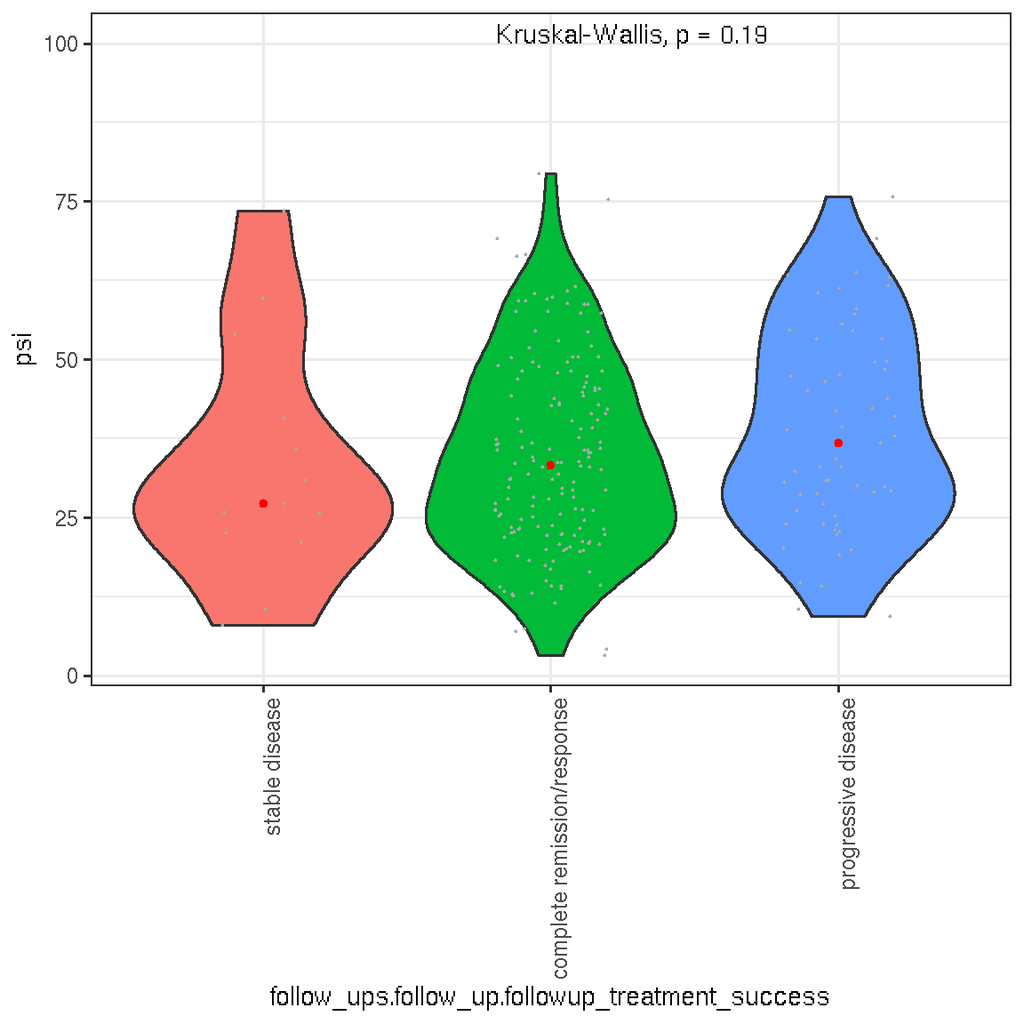

```r
clean$follow_ups.follow_up.followup_treatment_success = with(clean, reorder(follow_ups.follow_up.followup_treatment_success, psi, median))

ggplot(clean,
       aes(x=follow_ups.follow_up.followup_treatment_success,
           y=psi,
           fill=follow_ups.follow_up.followup_treatment_success))+
  geom_violin()   +
  theme_bw()+
  geom_jitter(shape=16,
              position=position_jitter(0.2),
              size=.5, color="darkgrey")     +
  stat_summary(fun=median, geom="point", size=1, color="red")  +
  stat_compare_means(label.y = 100, label.x=2)+
  theme(legend.position="none") +
  theme(axis.text.x = element_text(angle = 90, hjust = 1))
```

### 3.8.2 (2) follow_ups.follow_up.primary_therapy_outcome_success :

- Variable: follow_ups.follow_up.primary_therapy_outcome_success
- **Results**: there is a significant difference according KW test (pval 0.017)

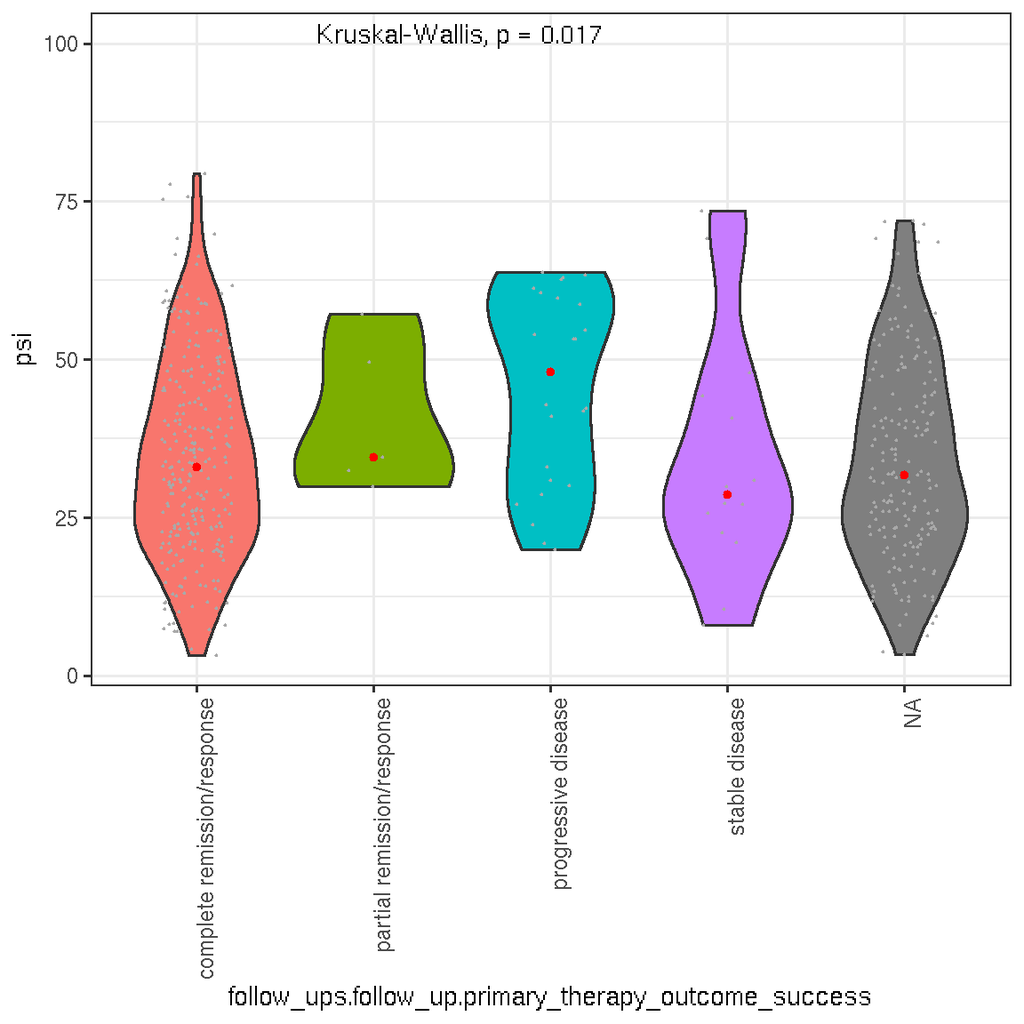

```r
ggplot(finalV,
       aes(x=follow_ups.follow_up.primary_therapy_outcome_success,
           y=psi,
           fill=follow_ups.follow_up.primary_therapy_outcome_success))+
  geom_violin()   +
  theme_bw()+
  geom_jitter(shape=16,
              position=position_jitter(0.2),
              size=.5, color="darkgrey")     +
  stat_summary(fun=median, geom="point", size=1, color="red")  +
  stat_compare_means(label.y = 100, label.x=2)+
  theme(legend.position="none") +
  theme(axis.text.x = element_text(angle = 90, hjust = 1))
```

```r
table(clean$follow_ups.follow_up.primary_therapy_outcome_success)
```

```
##
## complete remission/response  partial remission/response
##                         183                           2
##         progressive disease              stable disease
##                          20                          12
```

```r
#remuevo los unknown
clean<-finalV[!is.na(finalV$follow_ups.follow_up.primary_therapy_outcome_success),]
clean<-clean[clean$follow_ups.follow_up.primary_therapy_outcome_success!="partial remission/response",]
dim(clean)#234
```

```
## [1] 309  37
```

```r
table(clean$follow_ups.follow_up.primary_therapy_outcome_success)
```

```
##
## complete remission/response         progressive disease
##                         271                          24
##              stable disease
##                          14
```

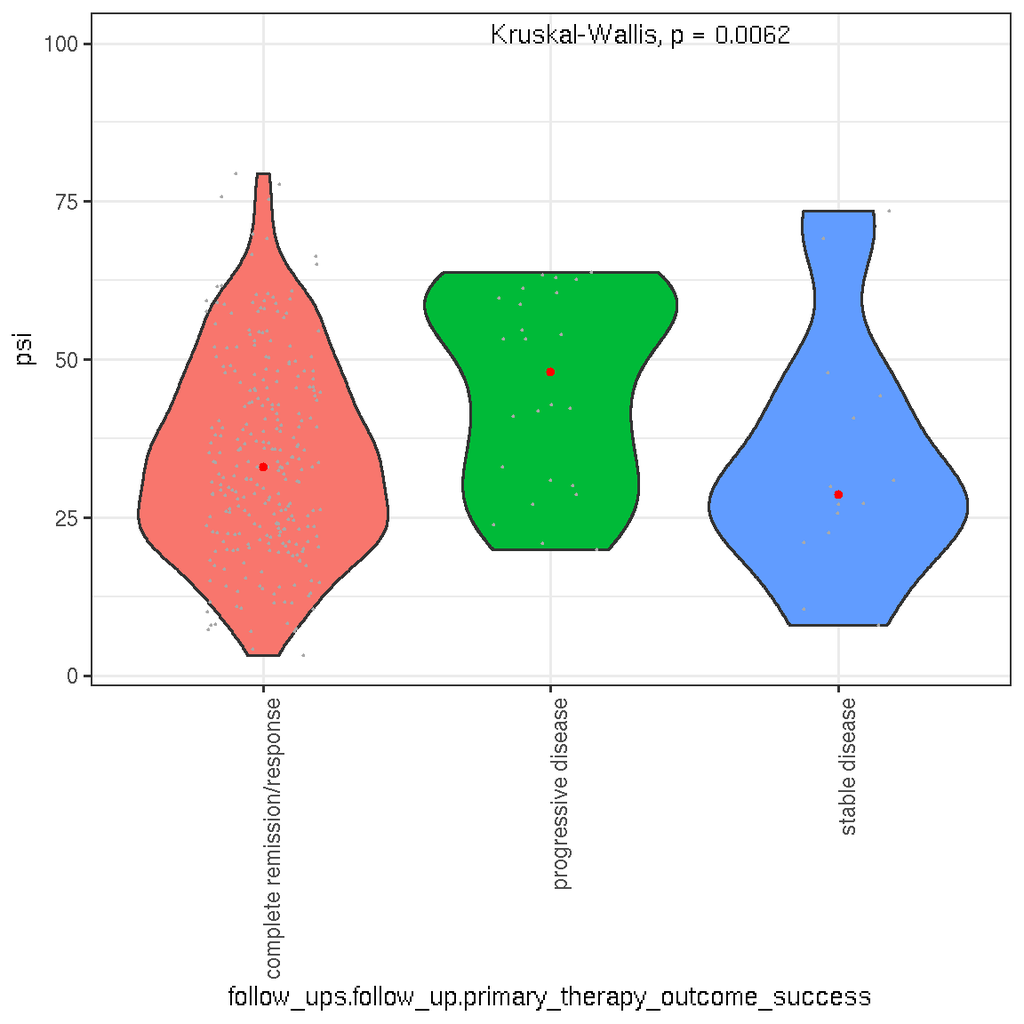

```r
ggplot(clean,
       aes(x=follow_ups.follow_up.primary_therapy_outcome_success,
           y=psi,
           fill=follow_ups.follow_up.primary_therapy_outcome_success))+
  geom_violin()   +
  theme_bw()+
  geom_jitter(shape=16,
              position=position_jitter(0.2),
              size=.5, color="darkgrey")     +
  stat_summary(fun=median, geom="point", size=1, color="red")  +
  stat_compare_means(label.y = 100, label.x=2)+
  theme(legend.position="none") +
  theme(axis.text.x = element_text(angle = 90, hjust = 1))
```

- (2b) Repito clean and reorder:
  - **Results** There is a clear difference, high PSI at more progressive stages (KW test, pval 0.0062)

```r
clean$follow_ups.follow_up.primary_therapy_outcome_success = with(clean, reorder(follow_ups.follow_up.primary_therapy_outcome_success, psi, median))
table(clean$follow_ups.follow_up.primary_therapy_outcome_success)
```

```
##
##              stable disease complete remission/response
##                          14                         271
##         progressive disease
##                          24
```

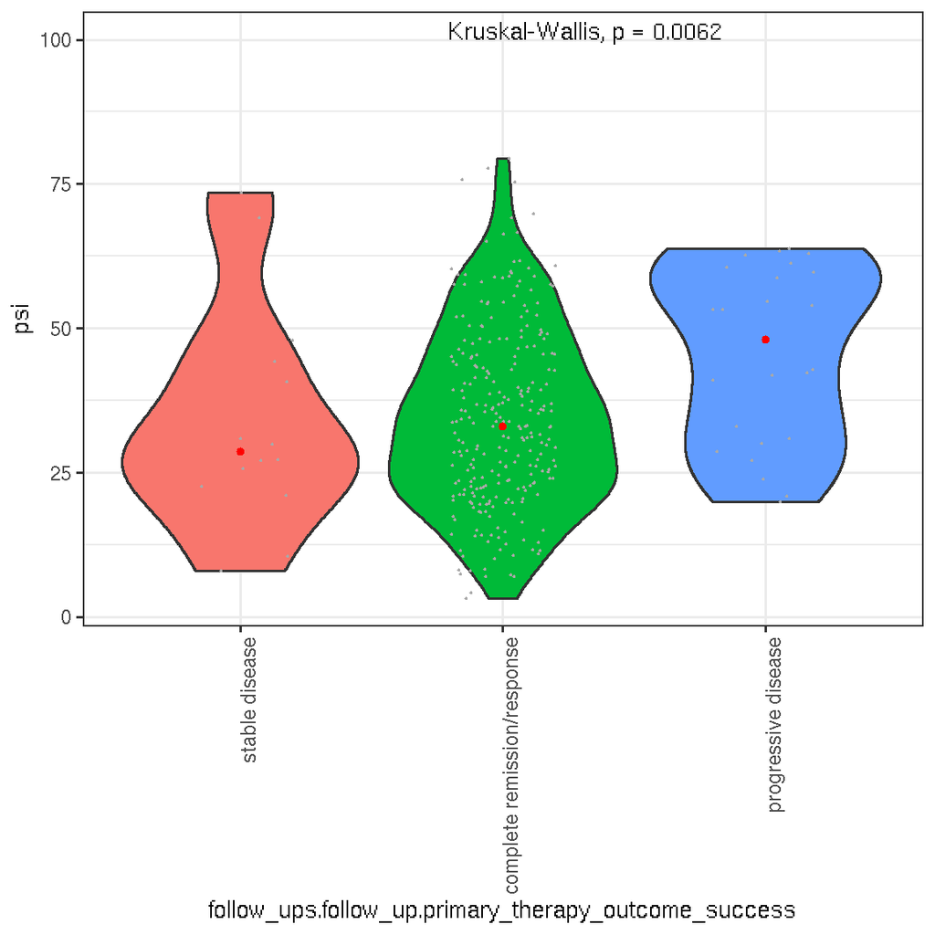

```r
ggplot(clean,
       aes(x=follow_ups.follow_up.primary_therapy_outcome_success,
           y=psi,
           fill=follow_ups.follow_up.primary_therapy_outcome_success))+
  geom_violin()   +
  theme_bw()+
  geom_jitter(shape=16,
              position=position_jitter(0.2),
              size=.5, color="darkgrey")     +
  stat_summary(fun=median, geom="point", size=1, color="red")  +
  stat_compare_means(label.y = 100, label.x=2)+
  theme(legend.position="none") +
  theme(axis.text.x = element_text(angle = 90, hjust = 1))
```

### 3.8.3 Primary therapy outcome success

```r
finalV$primary_therapy_outcome_success<-as.character(finalV$primary_therapy_outcome_success)

finalV$primary_therapy_outcome_success[is.na(finalV$primary_therapy_outcome_success)]<-"unknown"
table(finalV$primary_therapy_outcome_success)
```

```
##
## complete remission/response         progressive disease
##                         112                           9
##              stable disease                     unknown
##                           8                         365
```

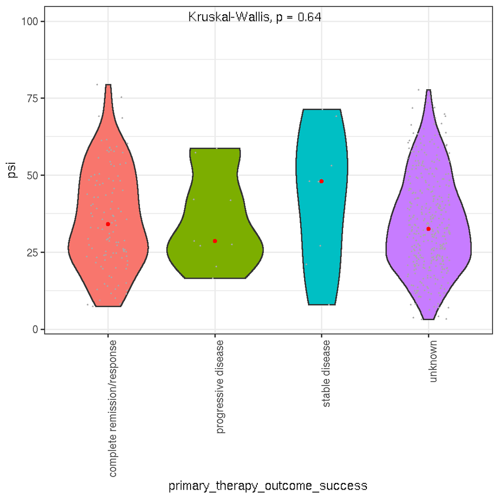

```r
ggplot(finalV,
       aes(x=primary_therapy_outcome_success,
           y=psi,
           fill=primary_therapy_outcome_success))+
  geom_violin()   +
  theme_bw()  +
  geom_jitter(shape=16,
              position=position_jitter(0.2),
              size=.5, color="darkgrey")     +
  stat_summary(fun=median, geom="point", size=1, color="red")  +
  stat_compare_means(label.y = 100, label.x=2)+
  theme(legend.position="none") +
  theme(axis.text.x = element_text(angle = 90, hjust = 1))
```

```r
finalV$primary_therapy_outcome_success<-as.character(finalV$primary_therapy_outcome_success)

finalV$primary_therapy_outcome_success[is.na(finalV$primary_therapy_outcome_success)]<-"unknown"
table(finalV$primary_therapy_outcome_success)
```

```
##
## complete remission/response         progressive disease
##                         112                           9
##              stable disease                     unknown
##                           8                         365
```

```r
clean<-finalV[finalV$primary_therapy_outcome_success!="unknown",]
clean<-clean[clean$primary_therapy_outcome_success!="partial remission/response",]
clean<-clean[!is.na(clean$primary_therapy_outcome_success),]
table(clean$primary_therapy_outcome_success)
```

```
##
## complete remission/response         progressive disease
##                         112                           9
##              stable disease
##                           8
```

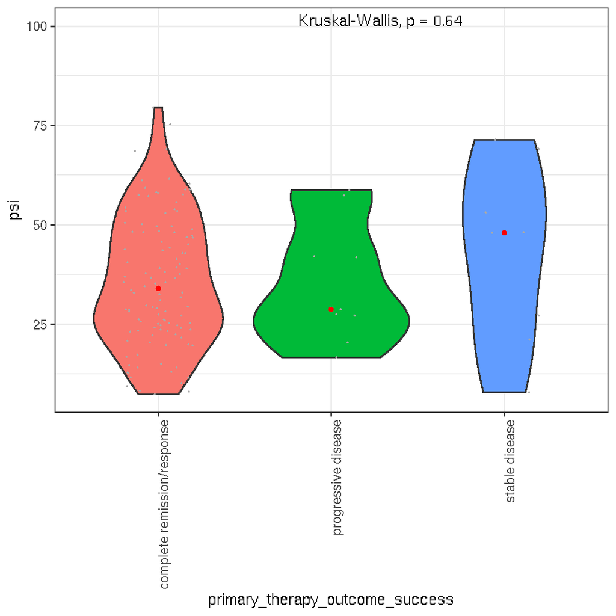

```r
ggplot(clean,
       aes(x=primary_therapy_outcome_success,
           y=psi,
           fill=primary_therapy_outcome_success))+
  geom_violin()   +
  theme_bw()  +
  geom_jitter(shape=16,
              position=position_jitter(0.2),
              size=.5, color="darkgrey")     +
  stat_summary(fun=median, geom="point", size=1, color="red")  +
  stat_compare_means(label.y = 100, label.x=2)+
  theme(legend.position="none") +
  theme(axis.text.x = element_text(angle = 90, hjust = 1))
```

- (3b) repito order

```r
table(clean$primary_therapy_outcome_success)
```

```
##
## complete remission/response         progressive disease
##                         112                           9
##              stable disease
##                           8
```

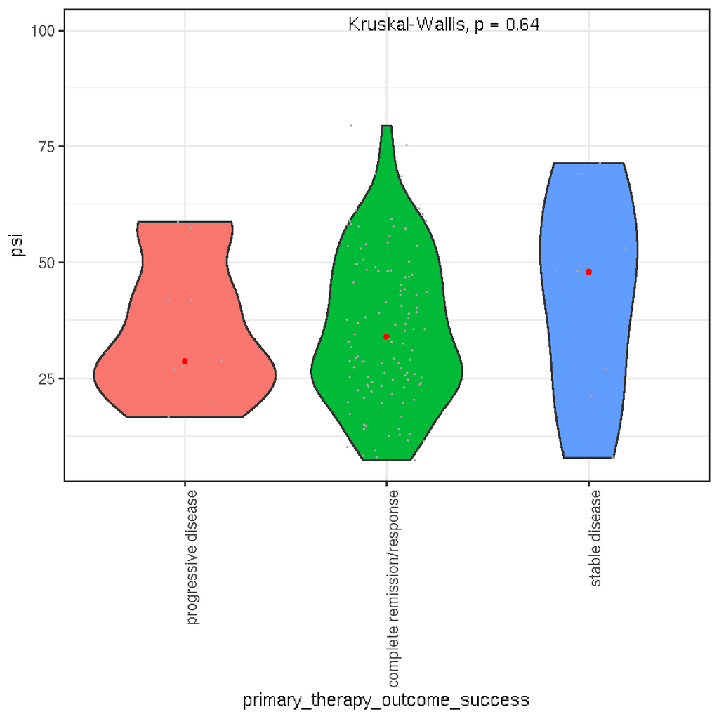

```r
clean$primary_therapy_outcome_success = with(clean, reorder(primary_therapy_outcome_success, psi, median))

ggplot(clean,
       aes(x=primary_therapy_outcome_success,
           y=psi,
           fill=primary_therapy_outcome_success))+
  geom_violin()   +
  theme_bw()  +
  geom_jitter(shape=16,
              position=position_jitter(0.2),
              size=.5, color="darkgrey")     +
  stat_summary(fun=median, geom="point", size=1, color="red")  +
  stat_compare_means(label.y = 100, label.x=2)+
  theme(legend.position="none") +
  theme(axis.text.x = element_text(angle = 90, hjust = 1))
```

## 3.9 Neoplasm cancer status

We want to check if there were any difference according tumor types. There is not significant difference (WT, pval 0.9)

```r
finalV$person_neoplasm_cancer_status<-as.character(finalV$person_neoplasm_cancer_status)
finalV$person_neoplasm_cancer_status[is.na(finalV$person_neoplasm_cancer_status)]<-"unknown"
print("Before cleaning")
```

```
## [1] "Before cleaning"
```

```r
table(finalV$person_neoplasm_cancer_status)
```

```
##
## tumor free    unknown with tumor
##        306        109         79
```

```r
#remvove unknown
finalVNotUnknown<-finalV[finalV$person_neoplasm_cancer_status!="unknown",]
finalVNotUnknown<-finalVNotUnknown[!is.na(finalV$person_neoplasm_cancer_status),]
finalVNotUnknown<-finalVNotUnknown[finalVNotUnknown$person_neoplasm_cancer_status!="NA",]
print("After cleaning")
```

```
## [1] "After cleaning"
```

```r
table(finalVNotUnknown$person_neoplasm_cancer_status)
```

```
##
## tumor free with tumor
##        306         79
```

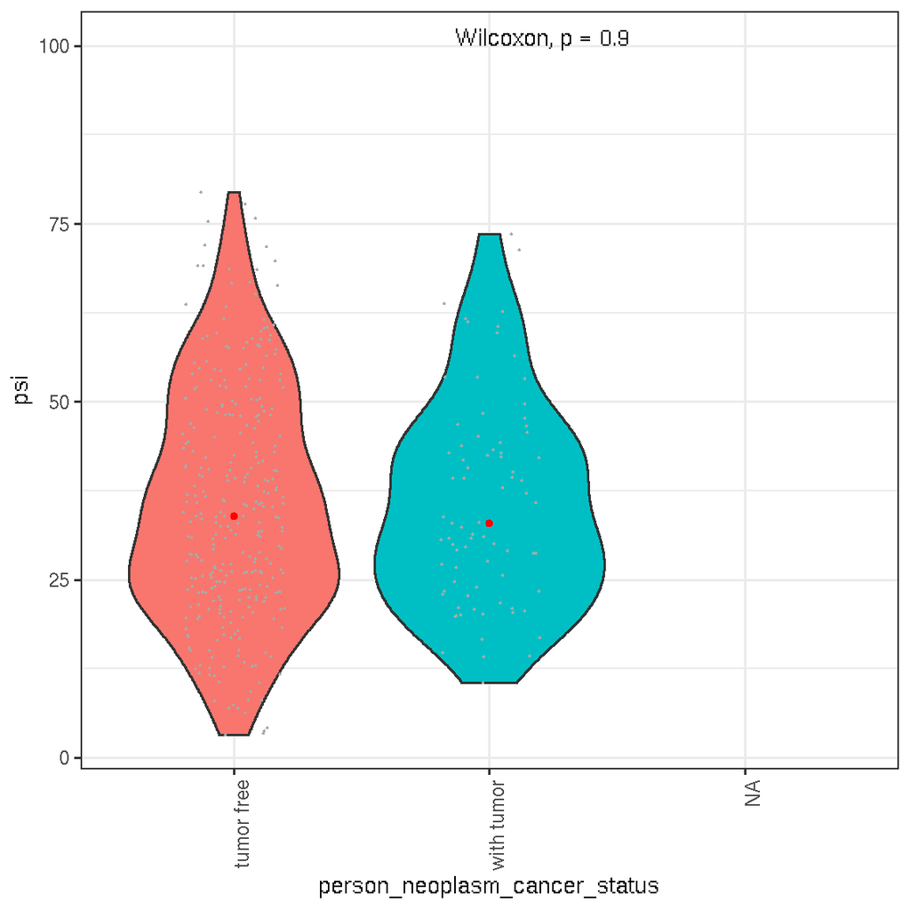

```r
ggplot(finalVNotUnknown,
       aes(x=person_neoplasm_cancer_status,
           y=psi,
           fill=person_neoplasm_cancer_status ))+
  geom_violin()   +
  theme_bw()+
  geom_jitter(shape=16,
              position=position_jitter(0.2),
              size=.5, color="darkgrey")     +
  stat_summary(fun=median, geom="point", size=1, color="red")  +
  stat_compare_means(label.y = 100, label.x=2)+
  theme(legend.position="none") +
  theme(axis.text.x = element_text(angle = 90, hjust = 1))
```

## 3.10 Sample types

```r
finalV$samples.sample.2.sample_type<-as.character(finalV$samples.sample.2.sample_type)
finalV$samples.sample.2.sample_type[is.na(finalV$samples.sample.2.sample_type)]<-"unknown"
table(finalV$samples.sample.2.sample_type)
```

```
##
## blood derived normal         ffpe scrolls        primary tumor
##                  309                    3                    1
##  solid tissue normal
##                  181
```

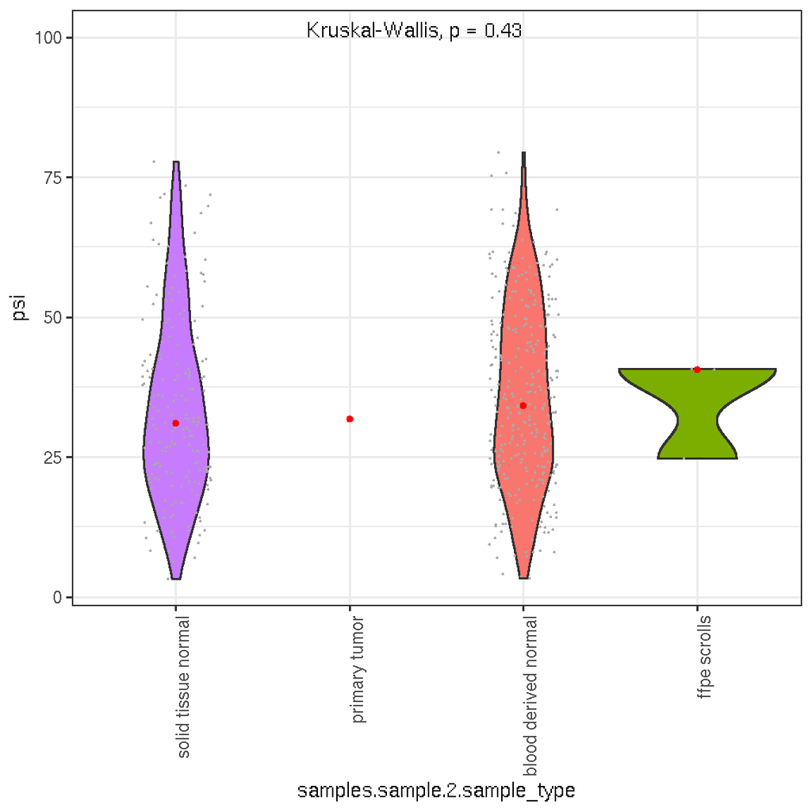

```r
#order:
finalV$samples.sample.2.sample_type = with(finalV, reorder(samples.sample.2.sample_type, psi, median))

ggplot(finalV,
       aes(x=samples.sample.2.sample_type, y=psi, fill=samples.sample.2.sample_type))+
  geom_violin()   +
  theme_bw()+
  geom_jitter(shape=16,
              position=position_jitter(0.2),
              size=.5, color="darkgrey")     +
  stat_summary(fun=median, geom="point", size=1, color="red")  +
  stat_compare_means(label.y = 100, label.x=2)+
  theme(legend.position="none") +
  theme(axis.text.x = element_text(angle = 90, hjust = 1))
```

## 3.11 Smokers

Explore if there is any relationship between PSI and Smoke. There are 417 patients which reported: “number pack years smoked”

```r
smoking<-finalV[!is.na(finalV$number_pack_years_smoked),]
dim(smoking)
```

```
## [1] 417  37
```

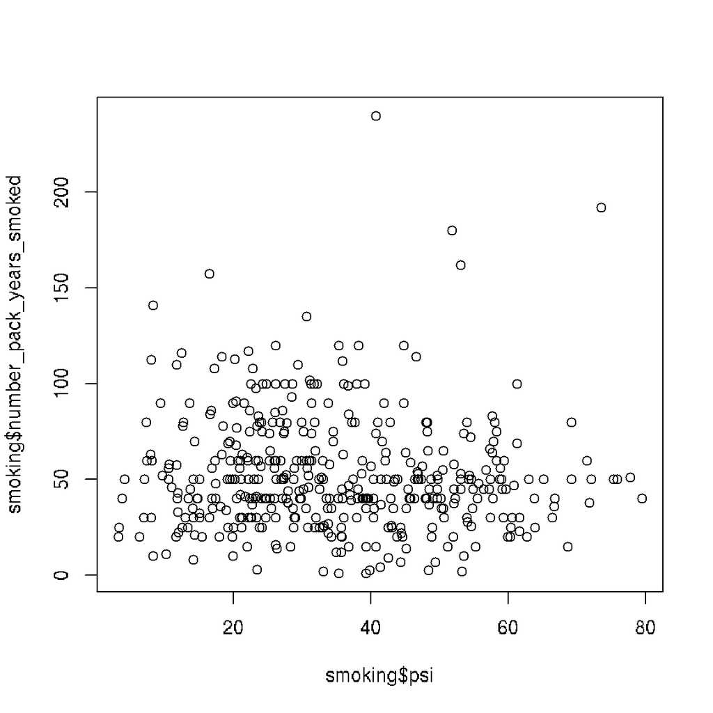

```r
plot(smoking$psi, smoking$number_pack_years_smoked)
```

```r
cor(smoking$psi, smoking$number_pack_years_smoked)
```

```
## [1] -0.06007164
```

```r
lm(smoking$psi ~ smoking$number_pack_years_smoked)
```

```
##
## Call:
## lm(formula = smoking$psi ~ smoking$number_pack_years_smoked)
##
## Coefficients:
##                      (Intercept)  smoking$number_pack_years_smoked
##                         36.39847                          -0.03217
```

# 4 Survival Plots

To study the impact of alternative splicing events on prognosis, Kaplan-Meier curves may be plotted for groups of patients separated by a given PSI cutoff for a given alternative splicing event. The optimal PSI cutoff maximises the significance of group differences in survival analysis (i.e. minimises the p-value of the log-rank tests of difference in survival between individuals whose samples have a PSI below and above that threshold).

## 4.1 (1st strategy) **optimalSurvivalCutoff**

We estimate optimo PSI using **psichomics optimalSurvivalCutoff** function. According to this function, **PSI = 50.83** is the value that best divide patients. We then defined:

- g0: PSI < 50.83: 396
- g1: PSI > 50.83: 87

Total number of cases: 483

```
## [1] 50.82815
```

```
## [1] 0.37
```

[interactive chart not shown]

```
## [1] 494
```

### 4.1.1 OS and RF Survival plots using optimo PSI (according psichomics: 50.83)

Overall Survival (OS) The event call is derived from “vital status” parameter. The time_to_event is in days, equals to days_to_death if patient deceased. In the case of a patient is still living, the time variable is the maximum(days_to_last_known_alive, days_to_last_followup). This pair of clinical parameters are called _EVENT and _TIME_TO_EVENT on the cancer browser.

In our case, we use these columns: + days_to_death, + days_to_last_followup, + days_to_last_known_alive

- Recurrence Free Survival (RFS) The event call is derived from “new_tumor_event_after_initial_treatment” parameter. The time_to_event is in days, equals to max (days_to_new_tumor_event_after_initial_treatment, days_to_tumor_recurrence) if there is an event. In the case of no event, the time variable is time of overall survival. The pair of clinical parameters are called _RFS and _RFS_IND on the cancer browser.

Source: https://groups.google.com/forum/#!topic/ucsc-cancer-genomics-browser/YvKnWZSsw1Q

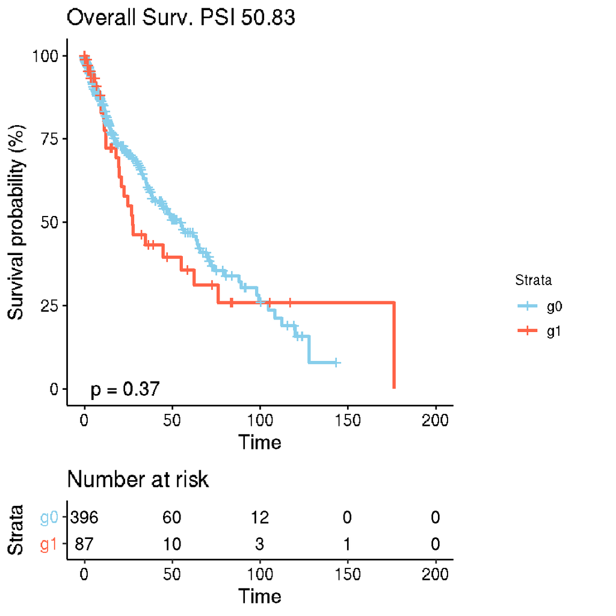

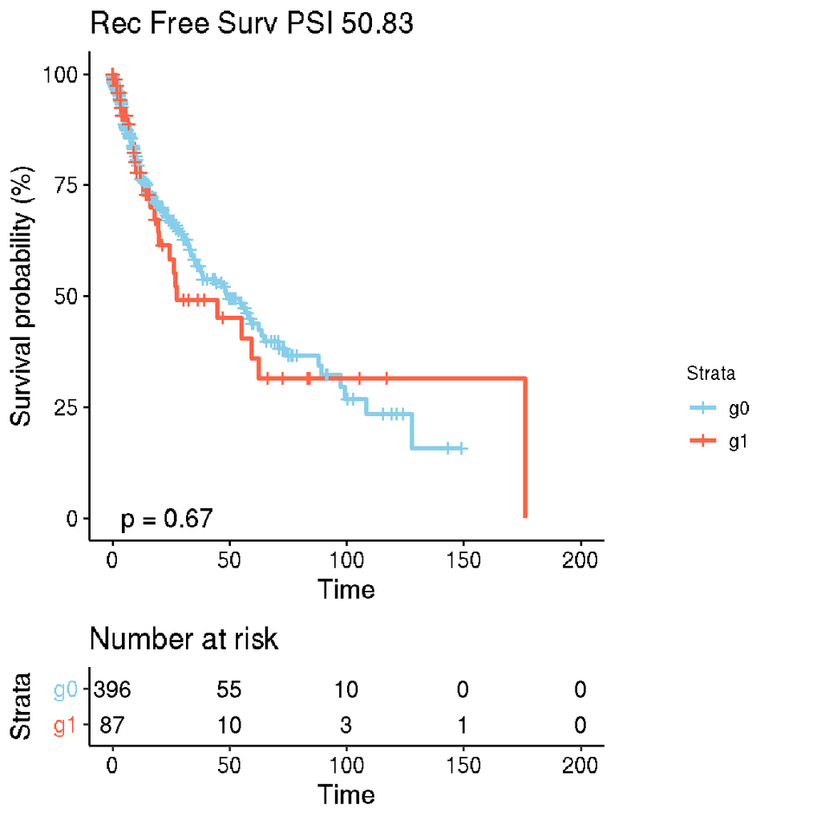

```r
title<-paste("Overall Surv. PSI 50.83")
ggsurvplot(fit,
           data = survivalNotNas,
           conf.int = F,
           pval = TRUE,
           fun = "pct",
           risk.table = TRUE,
           size = 1,
           palette = c("skyblue","tomato"),
           legend = "right",
           legend.labs = c("g0","g1"),
           title=title)
```

### 4.1.2 Compute optimo PSI inside G0 (psi < 50.83)

```
## [1] 15.93305
```

[interactive chart not shown]

#### 4.1.2.1 OS and RFS in G0 using optimo psi 15.93

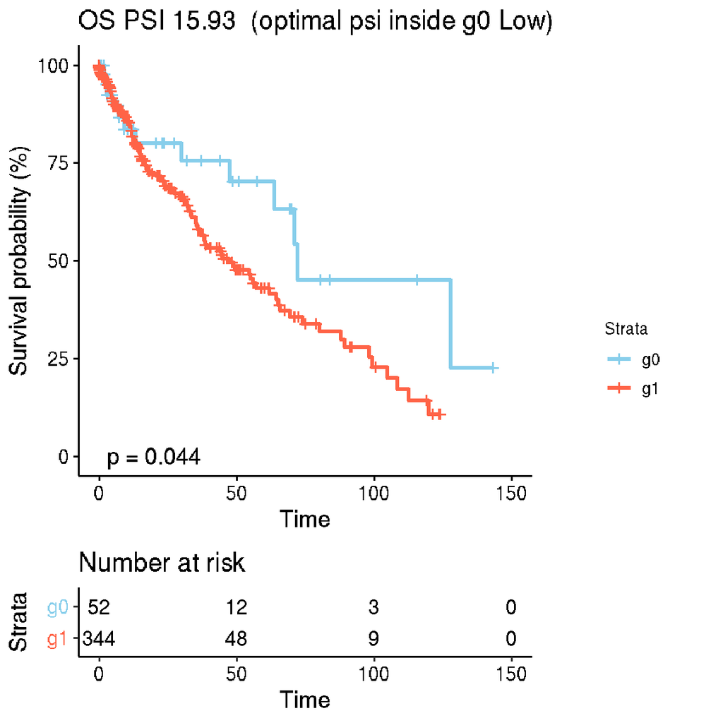

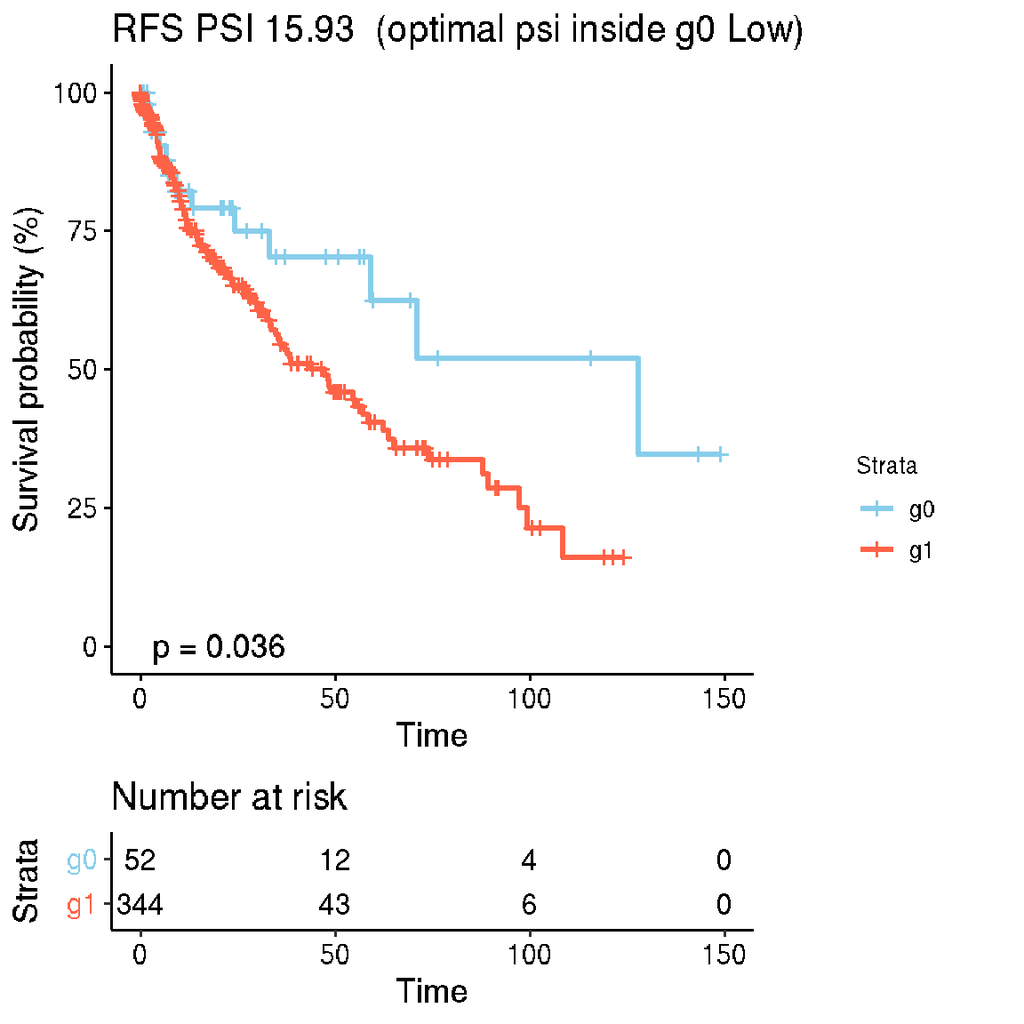

### 4.1.3 Compute optimo PSI inside G1 (psi >50.83)

```
## [1] 64.11472
```

```
## [1] 0.098
```

[interactive chart not shown]

#### 4.1.3.1 OS and RFS in G1 using optimo psi 64.11

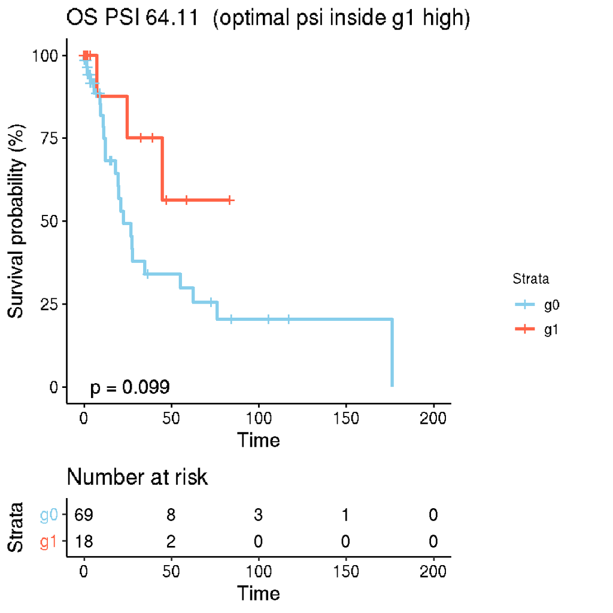

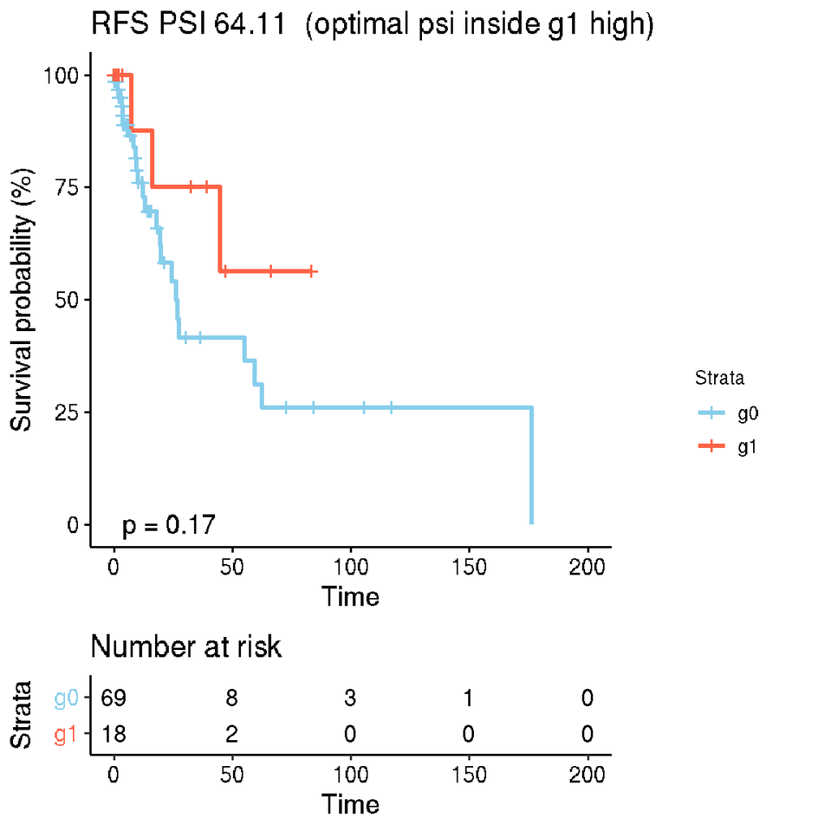

## 4.2 (2nd strategy) Scan pvalue across PSI values (whole dataset)

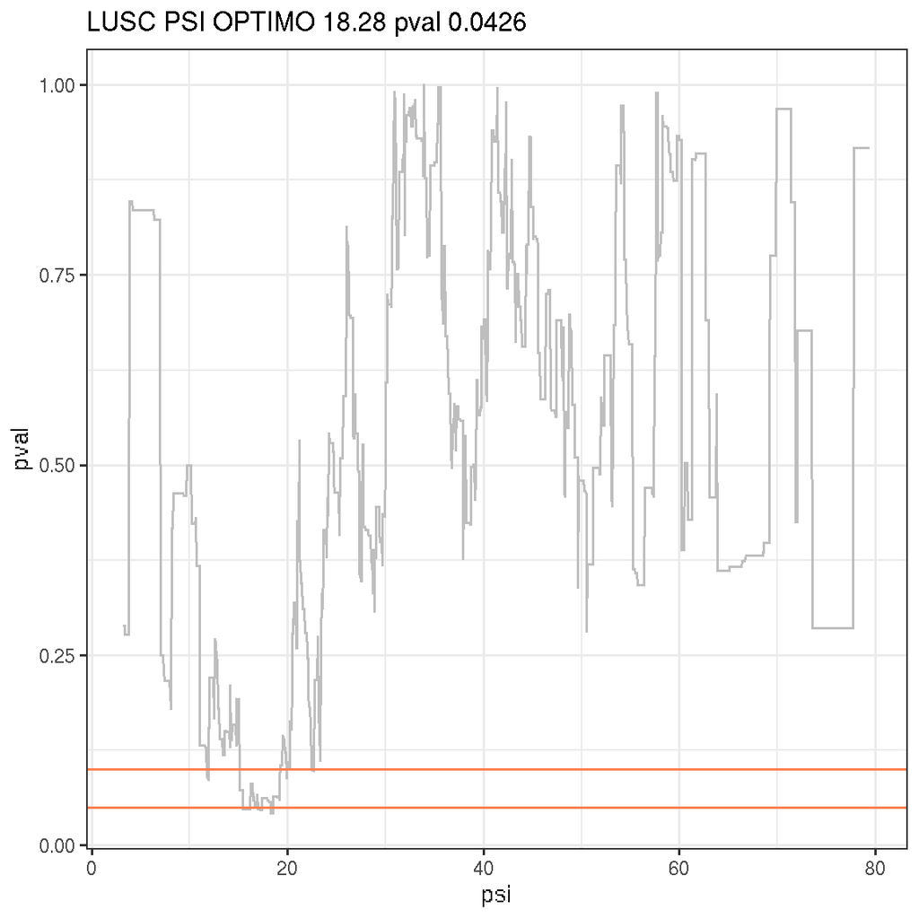

### 4.2.1 OS and RFS plots **whole dataset** using optimo PSI (18.28)

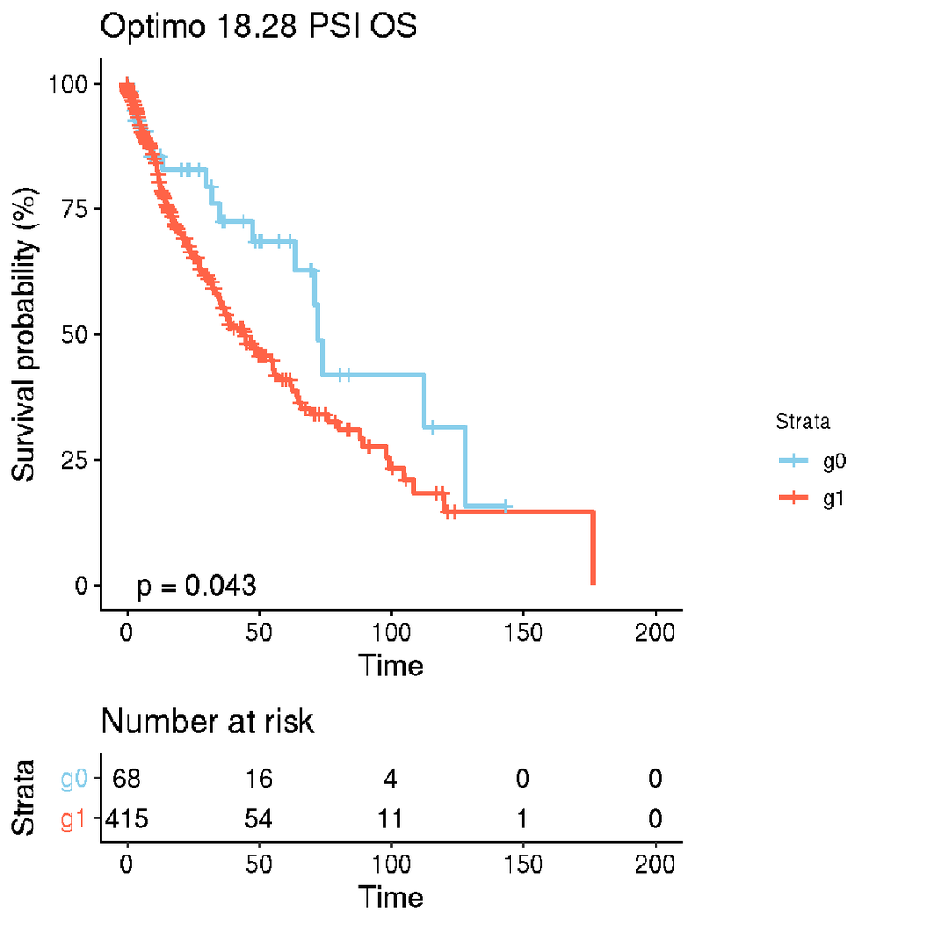

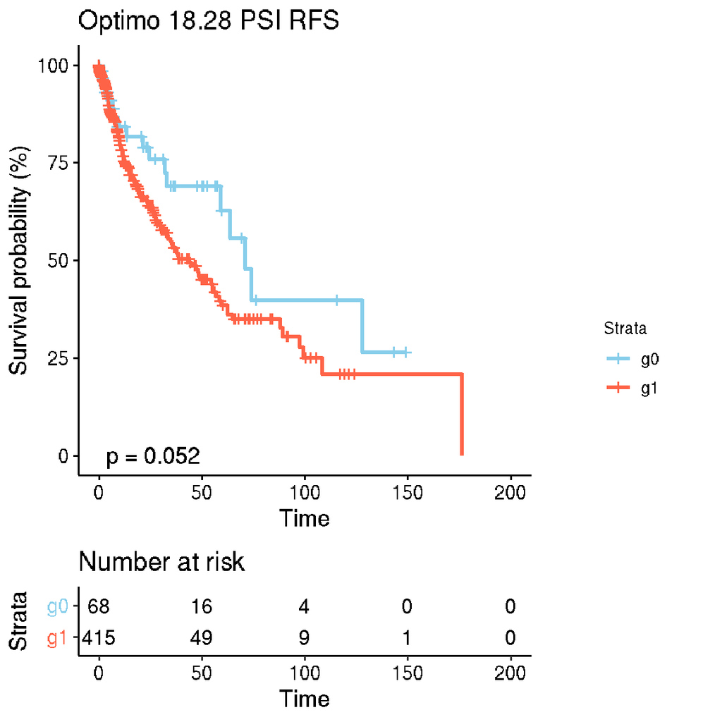